# R Assignment #2

Christopher David Desjardins

March 7, 2015

### Question 1

#### (a) - 2 points

The easiest item was number 5 with a difficulty of -1.6267111 and the hardest was number number 10 with a difficulty of 0.5295943.

#### (b) - 2 points

The 95% confidence interval was (-1.8854411, -1.3679811). Interpretation: We are 95% confident that the true item difficulty lies between these values for item number 5.

#### (c) - 1 point

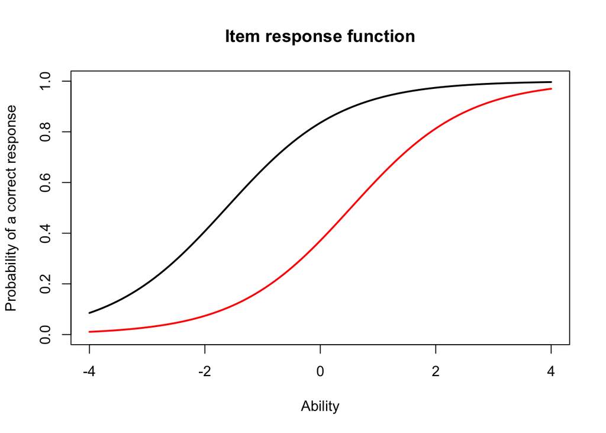

#### (d) - 2 points

The probabiliy of someone with an ability estimate of 0 getting the easiest item (the black line) correct is 0.8357186 and the hardest item correct (the red line) was 0.3706115

#### (e) - 2 points

The person who did the worst was 393 and there score was -3.9999468 and the person who did the best was 49 and there score 3.9999206.

#### (f) - 2 points

The 95% confidence interval was (-0.3206506, 8.3204917). Interpretation: We are 95% confident that the true score for person #49 lies between these values.

### Question 2

#### (a) - 1 point

Different for every student. For the remained of the answer key, we’ll assume you chose items 1, 3, and 5.

#### (b) - 1 point

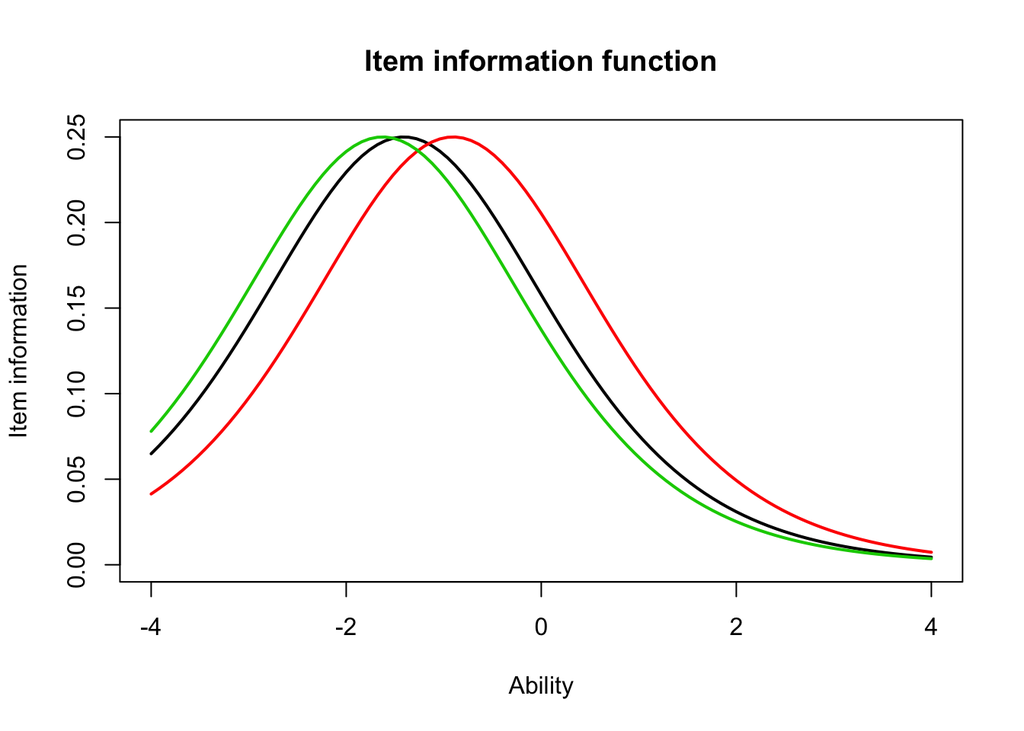

```r
plot(iif(est_params[c(1,3,5),]), co = NA)
```

#### (c) - 2 points

The items have the same shape and the same maximum amount of information. They differ by where the item is located.

#### (d) - 1 point

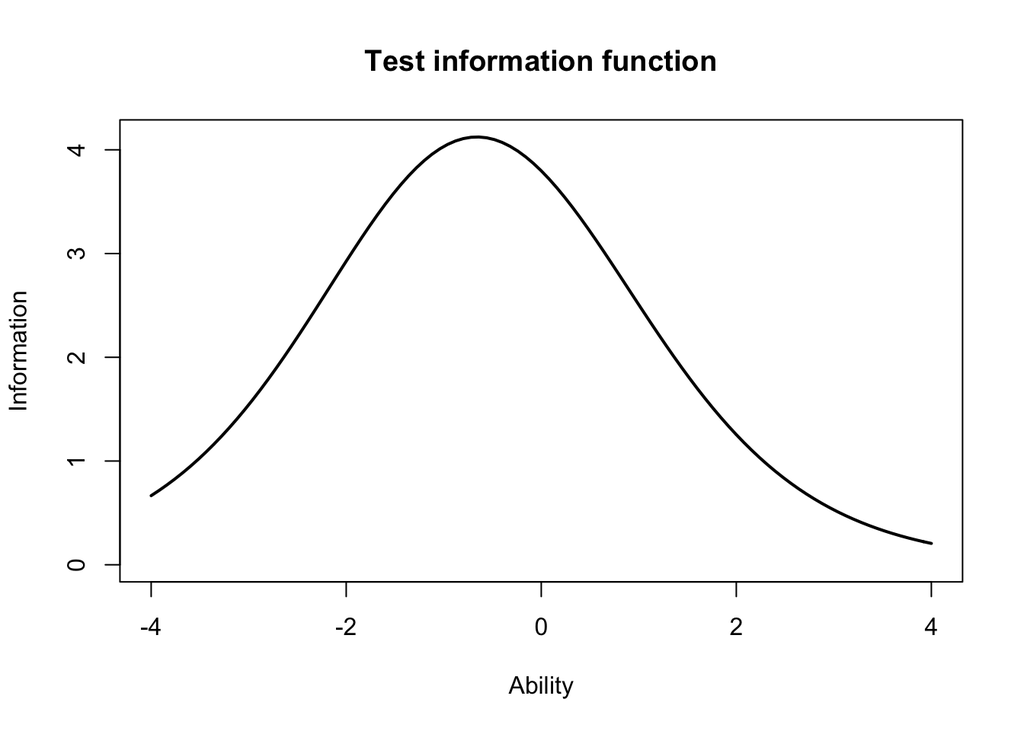

#### (e) - 1 point

The maximum amount of information is located around -0.64.

### Question 3

#### (a) - 2 points

The item with the lowest discrimination as number 12 with a discrimation of 0.332913 and the item with the highest discrimination was number 8 with a discrimination of 2.2881772.

#### (b) - 1 point

The easiest item in the 2PL was 1 with a difficulty of -2.000581 and the hardest item was number 10 with a difficulty of 0.4854289. Item 5 was the easiest in the Rasch and now item 1 is the easiest. 10 item was the most difficult in both.

#### (c) - 2 points

The correlation was 0.9709497. Yes, if interest in solely in estimating scores, the model give essential the same ranking and essentially the same information about scores.

#### (d) - 1 point

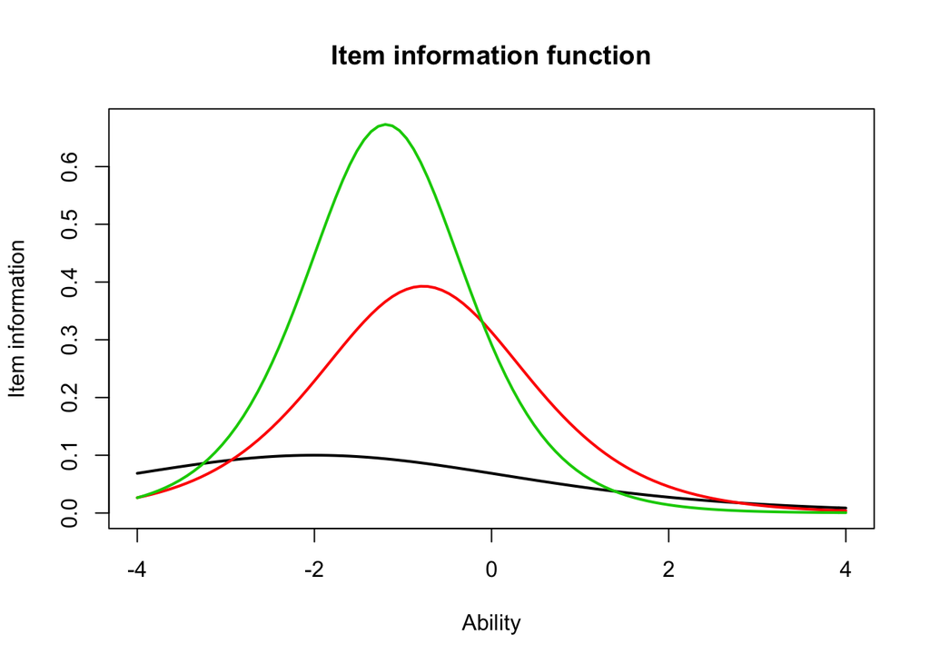

#### (e) - 2 points

Unlike the Rasch model, the shape and location of the information functions are completely different. Some functions look more like bell-curves, while others are more stretched out. This is because of the discrimination parameter. Comparing within the 2PL we see they have different shapes and centering and compared to the Rasch models, have different centers and shapes.